# Woody encroachment in wetlands from aerial photos

[VAAT-GJEN-02]

Authors

Affiliations

Bendik Sivertsen

Sállir Natur AS

Jesus Adrian Chimal-Ballesteros

Sállir Natur AS

Lasse Keetz

Field Geospatial AS

Published

November 26, 2026

**NoteStatus of this document**

This document follows the structure of NINA’s ecRxiv indicator template. It has **not** been submitted to or published on ecRxiv, and it is not a NINA product. The ecRxiv badges and the ecRxiv citation are therefore left out.

**TipMetadata**

Table 1: Indicator metadata

| Variable | Value |
| --- | --- |
| Indicator ID | VAAT-GJEN-02 |
| Indicator name | Woody encroachment in wetlands from aerial photos |
| Norwegian name | Gjengroing i våtmark (flyfoto) |
| Continent | Europe |
| Country | Norway |
| Ecosystem Condition Typology class | B2 - Structural State characteristics |
| Realm | Freshwater-Terrestrial (TF) |
| Biome | TF1 Palustrine wetlands biome |
| Ecosystem | TF1.6 Boreal, temperate and montane peat bogs; TF1.7 Boreal and temperate fens |
| Norwegian ecosystem | Våtmark |
| Year added | 2026 |
| Last update | 2026 |
| Status | complete |
| Version | 000.004 |
| Version comment | New method: CHMv2 calibrated to LiDAR, every 20 m cell of AR5 mire, same cells, height measure, references and scaling as VAAT-GJEN-01 |
| Normalised | Yes |
| Spatial aggregation pathway | Truncate/Scale/Transform (sigmoid) per 20 m cell - Aggregate (mean weighted by mire area) |
| Precision | Agreement with the LiDAR-based indicator at about 21,000 validation cells: sqrt(mean difference^2 + bootstrap SE^2) |

**TipLog**

- 24 Nov. 2026 - First version of this document. Population changed (version 000.003).
- 26 Nov. 2026 - New method (version 000.004): canopy height from CHMv2 calibrated to LiDAR, on every 20 m cell of AR5 mire instead of NiN wetland polygons. Version 000.003 is kept in the git history (tag `pre-docker-vaat-gjen-02-v000.004`).

## 1. Summary

1. **Background and rationale**: Open wetlands can become overgrown with trees and shrubs (Norwegian: *gjengroing*). VAAT-GJEN-01 measures this with LiDAR at a sample of points. LiDAR is rarely repeated nationally. This indicator measures the same characteristic from aerial photos, which are renewed far more often.
2. **Methods**: The canopy-height model CHMv2 (Meta and the World Resources Institute) estimates vegetation height from the national 50 cm orthophoto mosaic for all AR5 mire in Norway. The heights are corrected to the LiDAR scale with a simple calibration. Every 20 m cell of AR5 mire is then treated exactly as a VAAT-GJEN-01 sample cell: median height, the same references and the same scaling. Cell values are averaged, weighted by mire area.
3. **Interpretation**: A value of 1 means that the vegetation is no taller than in wetland in good condition. Values decreasing towards 0 mean that the vegetation approaches the height of forest.
4. **Results and development needs**: The national value is 0.953 (± 0.001), from 52,218,622 cells covering 13,867 km² of mire. It is lowest in Østlandet (0.932) and highest in Nord-Norge (0.976). With the same weighting of strata as VAAT-GJEN-01, the regional values are within about 0.01 of the LiDAR-based indicator. The photos are from different years in different parts of the country, and the model underestimates the height of tall stands.

## 2. About the underlying data

- **Imagery**: the national RGB orthophoto mosaic, 50 cm, product year 2025, from Field Geospatial AS. It is commercial and cannot be redistributed. The flights span 2015–2024.
- **Model**: CHMv2 (`facebook/dinov3-vitl16-chmv2-dpt-head`, open weights under the DINOv3 licence).
- **Population**: AR5 mire (land type 60, *myr*) from FKB-AR5 (NIBIO). The polygons themselves are not open and are not distributed.
- **Calibration and validation**: LiDAR canopy height (Kartverket DOM1 − DTM1, 1 m) at the VAAT-GJEN-01 sample cells.
- **Reference heights**: from VAAT-GJEN-01.
- **Other**: bioclimatic zones, OpenStreetMap buildings, the SSB 50 km grid and five regions, all as in VAAT-GJEN-01.

### 2.1 Spatial and temporal resolution and extent

All AR5 mire in mainland Norway, on a 20 m grid. Each cell is dated by the flight project visible there in the mosaic. The year label of the deliverables (2022) is the median flight year over the mire area of Norway. Median, earliest and latest flight year per unit are in the delivered tables.

### 2.2 Sampling design

No sampling: every 20 m cell that contains AR5 mire is used. The same cells are the population of VAAT-GJEN-01, which samples up to 1,000 of them per stratum.

### 2.3 Original units

Metres (calibrated canopy height).

### 2.4 Instructions for citing, using and accessing data

The tables of the national run are in the repository (`data/OpenS_data/orthophoto_chmv2_20m_cells/`), so the deliverables can be recreated without the imagery. A new run needs imagery of 0.5 m or finer, the AR5 mire layer and a GPU, see the README.

### 2.5 Additional comments about the dataset

The model choice and the calibration are explained in section 5 and in the README.

## 3. Indicator properties

### 3.1 Ecosystem Condition Typology Class (ECT)

B2 - structural state, as in NINA’s NO_GJEN_002: the indicator describes vegetation structure.

### 3.2 Ecosystem condition characteristic

Openness: in good condition, the wetland has few trees.

### 3.3 Collinearities with other indicators

VAAT-GJEN-01 measures the same characteristic in the same population with the same references, and the two should not be used together. The light indicator VAAT-FULI-01 may covary.

### 3.4 Impact factors

Drainage, nitrogen deposition and nutrient input, climate warming, and the end of traditional mowing and grazing.

### 3.5 Spatial aggregation

The variable is scaled per 20 m cell. Cell values are averaged per region, 50 km cell and nationally, each cell weighted by its area of AR5 mire. A second mean, `i_sample_design` in the tables, weights every region × bioclimatic-zone stratum equally, as VAAT-GJEN-01’s sample does.

## 4. Reference condition and levels

### 4.1 Reference condition

Wetland with little or no woody encroachment, under largely intact ecosystems (Nybø & Evju, 2017).

### 4.2 Reference levels

Taken unchanged from VAAT-GJEN-01:

- **X<sub>100</sub>**: the height of good-condition NiN wetland, evaluated at 30 m (median per polygon, then median per stratum).
- **X<sub>0</sub>**: the 90th percentile of forest height in AR5 forest, read as 20 m cells.
- **X<sub>60</sub>**: not defined. The limit 0.6 on the indicator scale is the platform default.

Both are measured with LiDAR. The calibration (section 5) puts the photo-based heights on the same scale.

Table 2: Reference heights, mire area and indicator value per stratum

| Region | Zone | X100 (m) | X0 (m) | Mire (km²) | Height (m) | Indicator |
| --- | --- | --- | --- | --- | --- | --- |
| Nord-Norge | Lavalpin sone (LA) | 0.05 | 3.84 | 122 | 0.07 | 0.988 |
| Nord-Norge | Mellomboreal sone (MB) | 0.32 | 6.63 | 1,050 | 0.27 | 0.972 |
| Nord-Norge | Nordboreal sone (NB) | 0.31 | 5.82 | 1,054 | 0.16 | 0.983 |
| Nord-Norge | Sørboreal sone (SB) | 0.17 | 6.99 | 384 | 0.31 | 0.966 |
| Midt-Norge | Boreonemoral sone (BN) | 0.04 | 8.51 | 298 | 0.40 | 0.959 |
| Midt-Norge | Mellomboreal sone (MB) | 0.59 | 7.73 | 2,092 | 0.37 | 0.968 |
| Midt-Norge | Nordboreal sone (NB) | 0.19 | 6.48 | 1,207 | 0.25 | 0.971 |
| Midt-Norge | Sørboreal sone (SB) | 0.63 | 9.35 | 972 | 0.78 | 0.939 |
| Vestlandet | Boreonemoral sone (BN) | 0.12 | 11.20 | 320 | 0.99 | 0.925 |
| Vestlandet | Mellomboreal sone (MB) | 0.30 | 10.12 | 190 | 0.42 | 0.978 |
| Vestlandet | Nordboreal sone (NB) | 0.07 | 9.27 | 62 | 0.24 | 0.988 |
| Vestlandet | Sørboreal sone (SB) | 0.11 | 10.65 | 201 | 0.59 | 0.961 |
| Østlandet | Boreonemoral sone (BN) | 1.56 | 11.33 | 160 | 2.20 | 0.869 |
| Østlandet | Lavalpin sone (LA) | 0.11 | 4.85 | 189 | 0.07 | 0.991 |
| Østlandet | Mellomboreal sone (MB) | 0.56 | 10.51 | 1,411 | 1.29 | 0.902 |
| Østlandet | Nordboreal sone (NB) | 0.13 | 6.18 | 2,403 | 0.25 | 0.970 |
| Østlandet | Sørboreal sone (SB) | 1.83 | 11.31 | 544 | 2.44 | 0.839 |
| Sørlandet | Boreonemoral sone (BN) | 1.72 | 10.97 | 302 | 1.47 | 0.918 |
| Sørlandet | Mellomboreal sone (MB) | 0.88 | 9.59 | 255 | 0.41 | 0.980 |
| Sørlandet | Nordboreal sone (NB) | 0.17 | 6.46 | 304 | 0.23 | 0.979 |
| Sørlandet | Sørboreal sone (SB) | 1.29 | 9.93 | 349 | 0.79 | 0.952 |

#### 4.2.1 Spatial resolution and validity

Reference levels vary by region and bioclimatic zone. Cells in strata without reference values are left out, as VAAT-GJEN-01 leaves out its points there (111,694 cells). So are cells whose centre lies outside the map of regions and zones (829,046 cells). In total, 13,867 of 14,119 km² of AR5 mire are scored.

## 5. Uncertainties

### 5.1 Model and calibration

The model was chosen after comparing CHMv2 with the model of the earlier version (CHMv1, Meta HighResCanopyHeight) at 25,027 VAAT-GJEN-01 sample cells with LiDAR heights, using the median per 20 m cell:

| Model | r | Mean error | Mean abs. error | < 0.5 m | 0.5–2 m | 2–5 m | > 5 m |
| --- | --- | --- | --- | --- | --- | --- | --- |
| CHMv1 | 0.80 | −0.22 m | 0.35 m | 0.05 m | 0.84 m | 1.78 m | 3.74 m |
| CHMv2, uncorrected | 0.86 | +0.57 m | 0.64 m | 0.14 m | 2.26 m | 3.74 m | 3.86 m |
| CHMv2, corrected | 0.86 | 0.00 m | 0.30 m | 0.08 m | 0.94 m | 1.14 m | 2.57 m |

The last four columns are the mean absolute error by LiDAR height class. CHMv2 overestimates height by a nearly constant factor, so a linear correction works: LiDAR height = max(0, -0.0127 + 0.5336 × CHMv2 height). Tested on one region at a time with the fit made on the other four, it performs as well as on its own data, and the slope varies little between regions (0.49–0.55). CHMv1 is about as accurate on low mire, but cannot be improved by a correction and needs about two weeks nationally on CPU; CHMv2 took about 11 hours on one GPU.

### 5.2 General uncertainties

- **Tall stands.** After correction, heights above 5 m are underestimated by about 1.4 m on average. This is the usual effect of a correction fitted on a noisy predictor; it is unbiased for a given model height, not for a given true height.
- **Imagery.** Photo year and season vary across the mosaic. Each unit’s flight years are reported with the results.
- **Time between photo and LiDAR.** Calibration and validation use LiDAR that is often several years older or newer than the photo. Clear-cuts or growth in between count as model error.
- **The index saturates.** Most cells of open mire score 1, because the sigmoid is flat near the reference.

### 5.3 Reported uncertainties

`sd` is the agreement with the LiDAR-based indicator. At each of 21,023 validation cells, the indicator is computed from the LiDAR height and from the calibrated photo-based height of the national map, with the calibration fitted without the cell’s region. Per region and nationally, `sd` = √(mean difference² + SE²), with SE from 1,000 bootstrap resamples of the cells. A 50 km cell gets the value of the region that holds most of its mire. The value does not include errors in the LiDAR heights or in the reference heights.

Table 3: Photo-based against LiDAR-based indicator at the validation cells

| Region | Validation cells | Indicator, LiDAR | Indicator, photo | Difference | sd |
| --- | --- | --- | --- | --- | --- |
| Norge | 21,023 | 0.949 | 0.948 | -0.001 | 0.001 |
| Nord-Norge | 4,004 | 0.980 | 0.976 | -0.005 | 0.005 |
| Midt-Norge | 4,003 | 0.960 | 0.953 | -0.008 | 0.008 |
| Vestlandet | 4,004 | 0.958 | 0.962 | 0.003 | 0.004 |
| Østlandet | 5,010 | 0.910 | 0.909 | -0.001 | 0.002 |
| Sørlandet | 4,002 | 0.945 | 0.949 | 0.004 | 0.004 |

## 6. References

Nybø, S., & Evju, M. (Eds.). (2017). *Fagsystem for fastsetting av god økologisk tilstand: Forslag fra et ekspertråd*. Ekspertrådet for økologisk tilstand.

Tolan, J., Yang, H.-I., Nosarzewski, B., Couairon, G., Vo, H. V., Brandt, J., Spore, J., Majumdar, S., Haziza, D., Vamaraju, J., Moutakanni, T., Bojanowski, P., Johns, T., White, B., Tiecke, T., & Couprie, C. (2024). Very high resolution canopy height maps from RGB imagery using self-supervised vision transformer and convolutional decoder trained on aerial lidar. *Remote Sensing of Environment, 300*, 113888. https://doi.org/10.1016/j.rse.2023.113888 (CHMv1, used in version 000.003 and in the model comparison)

CHMv2: Meta and the World Resources Institute, canopy-height model built on DINOv3, https://huggingface.co/facebook/dinov3-vitl16-chmv2-dpt-head.

The indicator follows NINA’s indicator documents NO_GJEN_002 by Gray, Mienna and Venter, and NO_GJEN_001.

## 7. Import and prepare datasets

The code in chapters 7, 9 and 11 is read from the scripts in the repository when this document is rendered. It is shown, but not executed. The results in chapter 10 are read from the files those scripts wrote. `docker/run_VAAT-GJEN-02_deliverables.sh` runs everything in order.

### 7.1 National canopy-height map

Every 256 m block of the mosaic within 30 m of AR5 mire is predicted on the GPU, with 40 m of surrounding image for context. The result is a 0.5 m height map (cm) of all mire plus a 30 m strip, so that edge cells are complete.

```python
"""National canopy-height map over all AR5 mire (VAAT-GJEN-02), on GPU.

Runs one model over every 256 m block of the orthophoto mosaic that lies
within 30 m of an AR5 mire polygon, and writes canopy height in cm at 0.5 m
for the pixels within 30 m of mire (other pixels: nodata). The 30 m buffer
keeps every 20 m cell around a mire point complete (VAAT-GJEN-01's sample cells
can reach up to 28.3 m from their point).

Models (--model):
  chmv1  Meta HighResCanopyHeight, aerial checkpoint compressed_SSLhuge_aerial.pth
         (the model of the published VAAT-GJEN-02 run). Its int8 layers are
         converted back to float so it runs on GPU (checked against the CPU
         int8 path on 2,000 points: same accuracy against LiDAR). Input as
         published: 256 x 256 px tiles at 0.5 m, four per block, no overlap.
  chmv2  Meta/WRI CHMv2 (facebook/dinov3-vitl16-chmv2-dpt-head). The block plus
         a 40 m margin (672 px) is resampled to 0.6 m (560 px), the resolution
         CHMv2 was trained on, predicted in one pass, resampled back to 0.5 m
         and cropped to the block, so block edges have context.
Both: ImageNet-style normalisation (0.420, 0.411, 0.296) / (0.213, 0.156, 0.143),
bf16 on GPU. Output is the RAW model height (no calibration).

Layout: blocks are the mosaic's own 512 x 512 px tiles (so every read is
aligned to them), grouped into chunks of 50 x 50 blocks (12.8 km). Each chunk
is written to a local staging folder, copied to the output folder when done,
and recorded in chunks/<chunk>.json. A rerun skips finished chunks.
Reads that fail are retried after 10, 30 and 90 s; a block that still fails
is listed in the chunk's json, and the chunk's file is named
<chunk>.INCOMPLETE.tif so it is redone by the next run.

Output folder (--out): <model>/chunks/*.tif, *.json; <model>/chm_<model>.vrt;
<model>/provenance.json; block_mask_ar5_30m.npy (shared between models).
"""
import argparse, collections, datetime, hashlib, json, os, queue, shutil, subprocess, sys, threading, time
os.environ.setdefault("GDAL_CACHEMAX", "4096")
import warnings
import numpy as np
import rasterio
from rasterio.errors import NotGeoreferencedWarning
from rasterio.features import rasterize
warnings.filterwarnings("ignore", category=NotGeoreferencedWarning)   # rasterize's in-memory raster, harmless
from rasterio.transform import Affine
from rasterio.windows import Window
import shapely
import pyogrio
import torch
import torch.nn.functional as F

BLOCK = 512            # px, = the mosaic's internal tile
RES = 0.5              # m
CHUNK = 50             # blocks per chunk side (12.8 km)
BUFFER_M = 30.0
NODATA = 65535
MEAN = (0.420, 0.411, 0.296)
STD = (0.213, 0.156, 0.143)

ap = argparse.ArgumentParser(description=__doc__, formatter_class=argparse.RawDescriptionHelpFormatter)
ap.add_argument("--model", choices=["chmv1", "chmv2"], required=True)
ap.add_argument("--ortho", required=True, help="orthophoto mosaic (8-bit RGB, 0.5 m, EPSG:25833)")
ap.add_argument("--ar5", required=True, help="AR5 mire GeoPackage (layer ar5_myr)")
ap.add_argument("--ar5-layer", default="ar5_myr")
ap.add_argument("--out", required=True, help="output folder (may be on the network drive)")
ap.add_argument("--staging", required=True, help="local folder for chunks being written")
ap.add_argument("--chmv1-dir", default="/chmv1", help="Meta HighResCanopyHeight code + saved_checkpoints")
ap.add_argument("--readers", type=int, default=24)
ap.add_argument("--batch", type=int, default=None, help="blocks per GPU batch (default 16 chmv1, 8 chmv2)")
ap.add_argument("--bbox", type=float, nargs=4, metavar=("XMIN", "YMIN", "XMAX", "YMAX"), help="only blocks in this box (tests)")
ap.add_argument("--max-chunks", type=int, default=0, help="stop after N chunks (tests)")
a = ap.parse_args()
batch_size = a.batch or (16 if a.model == "chmv1" else 8)
MARGIN = 0 if a.model == "chmv1" else 80          # px at 0.5 m on each side (chmv2: 40 m)
out_dir = os.path.join(a.out, a.model); os.makedirs(f"{out_dir}/chunks", exist_ok=True)
stage = os.path.join(a.staging, a.model); os.makedirs(stage, exist_ok=True)
dev = torch.device("cuda")
def log(*m):
    print(datetime.datetime.now().strftime("%H:%M:%S"), *m, flush=True)

# ---- grid -------------------------------------------------------------------------
with rasterio.open(a.ortho) as src:
    T, W, H, CRS = src.transform, src.width, src.height, src.crs
    assert abs(T.a - RES) < 1e-9 and abs(T.e + RES) < 1e-9, T
X0, Y0 = T.c, T.f
NBC, NBR = -(-W // BLOCK), -(-H // BLOCK)
BM = BLOCK * RES  # 256 m
def block_bounds(br, bc):
    x = X0 + bc * BM; y = Y0 - br * BM
    return x, y - BM, x + BM, y

# ---- 1. which blocks: AR5 mire rasterised at 32 m, grown by one cell (>= 30 m) ------
mask_path = os.path.join(a.out, "block_mask_ar5_30m.npy")
if not os.path.exists(mask_path):
    log("rasterising AR5 mire at 32 m to find the blocks (once, a few minutes)...")
    r32 = os.path.join(a.staging, "ar5_mire_32m.tif")
    ny, nx = NBR * 8, NBC * 8
    subprocess.run(["gdal_rasterize", "-q", "-l", a.ar5_layer, "-burn", "1", "-at", "-ot", "Byte", "-a_nodata", "0",
                    "-te", str(X0), str(Y0 - ny * 32), str(X0 + nx * 32), str(Y0), "-ts", str(nx), str(ny),
                    "-co", "COMPRESS=DEFLATE", "-co", "TILED=YES", a.ar5, r32], check=True)
    with rasterio.open(r32) as d:
        m = d.read(1) > 0
    g = m.copy()                                       # grow by one 32 m cell in all 8 directions
    g[1:] |= m[:-1]; g[:-1] |= m[1:]
    g2 = g.copy(); g2[:, 1:] |= g[:, :-1]; g2[:, :-1] |= g[:, 1:]
    blocks = g2.reshape(NBR, 8, NBC, 8).any(axis=(1, 3))
    np.save(os.path.join(a.staging, "block_mask.npy"), blocks)
    shutil.copyfile(os.path.join(a.staging, "block_mask.npy"), mask_path)
    os.remove(r32)
blocks = np.load(mask_path)
log(f"blocks within 30 m of AR5 mire: {blocks.sum():,} of {blocks.size:,}")

# chunk list (only chunks with blocks), optional bbox
todo = []
for cr in range(0, NBR, CHUNK):
    for cc in range(0, NBC, CHUNK):
        sub = np.argwhere(blocks[cr:cr + CHUNK, cc:cc + CHUNK])
        if a.bbox:
            keep = []
            for br, bc in sub + [cr, cc]:
                x0, y0, x1, y1 = block_bounds(br, bc)
                if x1 > a.bbox[0] and x0 < a.bbox[2] and y1 > a.bbox[1] and y0 < a.bbox[3]: keep.append((br, bc))
            sub = np.array(keep).reshape(-1, 2)
        else:
            sub = sub + [cr, cc]
        if len(sub):
            todo.append((cr, cc, [tuple(map(int, b)) for b in sub]))
def chunk_name(cr, cc): return f"r{cr // CHUNK:03d}_c{cc // CHUNK:03d}"
def chunk_done(cr, cc):
    f = f"{out_dir}/chunks/{chunk_name(cr, cc)}.json"
    if not os.path.exists(f): return False
    info = json.load(open(f))      # a chunk done in a --bbox test run is not done for another box / the full run
    return info.get("status") in ("complete", "empty") and info.get("bbox") == a.bbox
n_all = len(todo)
todo = [t for t in todo if not chunk_done(t[0], t[1])]
if a.max_chunks: todo = todo[:a.max_chunks]
n_blocks = sum(len(t[2]) for t in todo)
log(f"chunks: {n_all} with mire, {n_all - len(todo) if not a.max_chunks else 'n/a'} already done, "
    f"{len(todo)} to do ({n_blocks:,} blocks)")
if not todo:
    log("nothing to do")
```

```python
# ---- 2. AR5 polygons for the 0.5 m mask -----------------------------------------------
if todo:
    bb = a.bbox and (a.bbox[0] - 300, a.bbox[1] - 300, a.bbox[2] + 300, a.bbox[3] + 300)
    log("reading AR5 mire polygons...")
    _, _, wkb, _ = pyogrio.raw.read(a.ar5, layer=a.ar5_layer, columns=[], bbox=bb, read_geometry=True)
    geoms = shapely.from_wkb(wkb); del wkb
    tree = shapely.STRtree(geoms)
    log(f"{len(geoms):,} polygons")

# ---- 3. model -------------------------------------------------------------------------------
def sha256(path):
    h = hashlib.sha256()
    with open(path, "rb") as f:
        for b in iter(lambda: f.read(1 << 24), b""): h.update(b)
    return h.hexdigest()
mean_t = torch.tensor(MEAN, device=dev).view(1, 3, 1, 1); std_t = torch.tensor(STD, device=dev).view(1, 3, 1, 1)
if a.model == "chmv1":
    import torch.nn as nn
    sys.path.insert(0, a.chmv1_dir)
    from models.backbone import SSLVisionTransformer
    from models.dpt_head import DPTHead
    class SSLAE(nn.Module):  # Meta's inference.py, huge=True, classify=True
        def __init__(self):
            super().__init__()
            self.backbone = SSLVisionTransformer(embed_dim=1280, num_heads=20, out_indices=(9, 16, 22, 29), depth=32)
            self.decode_head = DPTHead(classify=True, in_channels=(1280,) * 4, embed_dims=1280,
                                       post_process_channels=[160, 320, 640, 1280])
        def forward(self, x):
            return 10 * self.decode_head(self.backbone(x))   # x10 as SSLModule
    ckpt_path = os.path.join(a.chmv1_dir, "saved_checkpoints", "compressed_SSLhuge_aerial.pth")
    ck = torch.load(ckpt_path, map_location="cpu", weights_only=False)
    sd = {}
    for k, v in ck.items():
        if k.endswith("._packed_params._packed_params"):            # int8 nn.Linear -> float
            base = k[: -len("._packed_params._packed_params")]
            sd[base + ".weight"] = v[0].dequantize()
            if v[1] is not None: sd[base + ".bias"] = v[1]
        elif not k.endswith((".scale", ".zero_point", "._packed_params.dtype")):
            sd[k] = v
    net = SSLAE().eval()
    res = net.load_state_dict(sd, strict=False)
    assert res.missing_keys == ["backbone.mask_token"] and not res.unexpected_keys, res
    net = net.to(dev)
    model_id = {"name": "Meta HighResCanopyHeight (CHMv1), aerial checkpoint, int8 layers dequantised",
                "checkpoint": ckpt_path, "checkpoint_sha256": sha256(ckpt_path)}
    def predict(x):                                     # x: (B,3,512,512) in [0,1]
        B = x.shape[0]
        t = x.reshape(B, 3, 2, 256, 2, 256).permute(0, 2, 4, 1, 3, 5).reshape(B * 4, 3, 256, 256)
        y = net((t - mean_t) / std_t).squeeze(1)        # (B*4,256,256)
        return y.reshape(B, 2, 2, 256, 256).permute(0, 1, 3, 2, 4).reshape(B, 512, 512)
else:
    from transformers import CHMv2ForDepthEstimation
    repo = "facebook/dinov3-vitl16-chmv2-dpt-head"
    rev = "37130c851a3cf6720f974490707059f5edaeed4e"   # the model version calibrated in src/chm_comparison
    net = CHMv2ForDepthEstimation.from_pretrained(repo, revision=rev).eval().to(dev)
    model_id = {"name": "CHMv2 (Meta/WRI), DINOv3 ViT-L + DPT head", "hf_repo": repo, "hf_commit": rev}
    def predict(x):                                     # x: (B,3,672,672) in [0,1] at 0.5 m
        x6 = F.interpolate(x, size=(560, 560), mode="bicubic", antialias=True, align_corners=False).clamp(0, 1)
        y = net(pixel_values=(x6 - mean_t) / std_t).predicted_depth          # (B,560,560) metres
        y = F.interpolate(y[:, None].float(), size=(672, 672), mode="bilinear", align_corners=False)[:, 0]
        return y[:, MARGIN:MARGIN + BLOCK, MARGIN:MARGIN + BLOCK]

# ---- 4. readers ---------------------------------------------------------------------------
_tl = threading.local()
def ortho():
    if not hasattr(_tl, "ds"): _tl.ds = rasterio.open(a.ortho)
    return _tl.ds
def retry(fn, what):
    err = None
    for wait in (10, 30, 90, None):
        try:
            return fn(), None
        except Exception as e:
            err = f"{type(e).__name__}: {e}"
            if wait is None: break
            log(f"retry in {wait}s: {what}: {err}")
            if hasattr(_tl, "ds"): del _tl.ds                    # reopen after a network error
            time.sleep(wait)
    return None, err
def read_block(br, bc):
    """-> (image uint8 (n,n,3) with margin, mire mask (512,512) bool, error)"""
    n = BLOCK + 2 * MARGIN
    c0, r0 = bc * BLOCK - MARGIN, br * BLOCK - MARGIN
    def f():
        ds = ortho()
        inside = c0 >= 0 and r0 >= 0 and c0 + n <= W and r0 + n <= H
        img = ds.read([1, 2, 3], window=Window(c0, r0, n, n), boundless=not inside, fill_value=255)
        assert img.shape == (3, n, n), img.shape
        return img
    img, err = retry(f, f"block r{br} c{bc}")
    if img is None: return None, None, err
    x0, y0, x1, y1 = block_bounds(br, bc)
    idx = tree.query(shapely.box(x0 - BUFFER_M, y0 - BUFFER_M, x1 + BUFFER_M, y1 + BUFFER_M))
    if len(idx) == 0:
        return img, np.zeros((BLOCK, BLOCK), bool), None
    clip = shapely.clip_by_rect(geoms[idx], x0 - BUFFER_M - 1, y0 - BUFFER_M - 1, x1 + BUFFER_M + 1, y1 + BUFFER_M + 1)
    buf = shapely.buffer(clip, BUFFER_M, quad_segs=4)
    buf = buf[~shapely.is_empty(buf)]
    mask = rasterize(((g, 1) for g in buf), out_shape=(BLOCK, BLOCK), transform=Affine(RES, 0, x0, 0, -RES, y1),
                     fill=0, dtype="uint8").astype(bool) if len(buf) else np.zeros((BLOCK, BLOCK), bool)
    return img, mask, None

# ---- 5. writer: one chunk file at a time, finalised in order ----------------------------
PROFILE = dict(driver="GTiff", dtype="uint16", count=1, nodata=NODATA, crs=CRS, tiled=True,
               blockxsize=BLOCK, blockysize=BLOCK, compress="ZSTD", predictor=2, zstd_level=9,
               BIGTIFF="IF_SAFER", SPARSE_OK=True, NUM_THREADS=8)
wq = queue.Queue(maxsize=64)
stats = {"blocks": 0, "written": 0, "failed": 0, "chunks": 0, "t_wait": 0.0, "t_gpu": 0.0}
def writer():
    ds, cur, info = None, None, None
    while True:
        item = wq.get()
        if item is None: break
        kind = item[0]
        if kind == "open":
            _, cr, cc, nb = item
            name = chunk_name(cr, cc)
            path = f"{stage}/{name}.tif"
            ds = rasterio.open(path, "w", width=CHUNK * BLOCK, height=CHUNK * BLOCK,
                               transform=Affine(RES, 0, X0 + cc * BM, 0, -RES, Y0 - cr * BM), **PROFILE)
            cur, info = (cr, cc, name, path), {"chunk": name, "bbox": a.bbox, "blocks": nb, "written": 0, "empty": 0, "failed": [], "t0": time.time()}
        elif kind == "block":
            _, br, bc, arr = item
            cr, cc = cur[0], cur[1]
            if arr is None: info["empty"] += 1
            else:
                ds.write(arr, 1, window=Window((bc - cc) * BLOCK, (br - cr) * BLOCK, BLOCK, BLOCK)); info["written"] += 1
        elif kind == "fail":
            info["failed"].append(item[1])
        elif kind == "close":
            ds.close(); ds = None
            cr, cc, name, path = cur
            info["seconds"] = round(time.time() - info.pop("t0"), 1)
            if info["failed"]:
                info["status"] = "incomplete"; dst = f"{out_dir}/chunks/{name}.INCOMPLETE.tif"
            elif info["written"] == 0:
                info["status"] = "empty"; dst = None
            else:
                info["status"] = "complete"; dst = f"{out_dir}/chunks/{name}.tif"
            if dst:
                shutil.copyfile(path, dst + ".part"); os.replace(dst + ".part", dst)
                if info["status"] == "complete" and os.path.exists(f"{out_dir}/chunks/{name}.INCOMPLETE.tif"):
                    os.remove(f"{out_dir}/chunks/{name}.INCOMPLETE.tif")
            os.remove(path)
            with open(f"{out_dir}/chunks/{name}.json", "w") as fh: json.dump(info, fh, indent=1)
            stats["chunks"] += 1; stats["failed"] += len(info["failed"])
        wq.task_done()
wt = threading.Thread(target=writer, daemon=True); wt.start()
```

```python
# ---- 6. main loop: readers -> GPU batches -> writer ------------------------------------------
from concurrent.futures import ThreadPoolExecutor
prov = {"started": datetime.datetime.now().isoformat(timespec="seconds"), "args": vars(a), "model": model_id,
        "ortho": {"path": a.ortho, "bytes": os.path.getsize(a.ortho)} if os.path.exists(a.ortho) else a.ortho,
        "ar5": {"path": a.ar5, "bytes": os.path.getsize(a.ar5), "mtime": os.path.getmtime(a.ar5)},
        "grid": {"x0": X0, "y0": Y0, "res": RES, "block_px": BLOCK, "chunk_blocks": CHUNK, "margin_px": MARGIN,
                 "buffer_m": BUFFER_M, "units": "cm", "nodata": NODATA},
        "code_commit": os.environ.get("CODE_COMMIT"), "torch": torch.__version__,
        "gpu": torch.cuda.get_device_name(0), "packages": {m: sys.modules[m].__version__ for m in ("numpy", "rasterio", "shapely") if m in sys.modules}}
if a.model == "chmv2":
    import transformers; prov["packages"]["transformers"] = transformers.__version__
json.dump(prov, open(f"{out_dir}/provenance_{prov['started'].replace(':', '')}.json", "w"), indent=1)

def run_batch(items):
    """items: list of (br, bc, img, mask); predict and queue for writing."""
    t0 = time.time()
    x = torch.from_numpy(np.stack([it[2] for it in items])).to(dev).float() / 255   # (B,3,n,n)
    with torch.no_grad(), torch.autocast("cuda", dtype=torch.bfloat16):
        y = predict(x).float().relu()
    cm = torch.round(y * 100).clamp(0, NODATA - 1).to(torch.int32).cpu().numpy().astype(np.uint16)
    for (br, bc, img, mask), arr in zip(items, cm):
        core = img[:, MARGIN:MARGIN + BLOCK, MARGIN:MARGIN + BLOCK]
        nodata = ~mask | (core == 255).all(axis=0)
        arr[nodata] = NODATA
        wq.put(("block", br, bc, arr))
    stats["t_gpu"] += time.time() - t0

t_start, last = time.time(), 0
pool = ThreadPoolExecutor(a.readers)
for ci, (cr, cc, blist) in enumerate(todo):
    wq.put(("open", cr, cc, len(blist)))
    futs = collections.deque(pool.submit(read_block, br, bc) for br, bc in blist)
    pending = []
    for br, bc in blist:
        t0 = time.time(); img, mask, err = futs.popleft().result(); stats["t_wait"] += time.time() - t0
        stats["blocks"] += 1
        if img is None:
            wq.put(("fail", {"block": [br, bc], "error": err})); log(f"FAILED block r{br} c{bc}: {err}"); continue
        if not mask.any():
            wq.put(("block", br, bc, None)); continue
        pending.append((br, bc, img, mask))
        if len(pending) == batch_size:
            run_batch(pending); pending = []
    if pending: run_batch(pending)
    wq.put(("close",))
    if time.time() - last > 60 or ci == len(todo) - 1:
        last = time.time(); el = last - t_start; rate = stats["blocks"] / el
        log(f"chunk {ci + 1}/{len(todo)}: {stats['blocks']:,}/{n_blocks:,} blocks, {rate:.1f} blocks/s, "
            f"ETA {(n_blocks - stats['blocks']) / max(rate, 1e-9) / 3600:.1f} h, failed blocks {stats['failed']} "
            f"(time waiting for reads {stats['t_wait'] / el:.0%}, GPU {stats['t_gpu'] / el:.0%})")
wq.put(None); wt.join(); pool.shutdown()

# ---- 7. VRT over all complete chunks, summary ----------------------------------------------------
def write_vrt(tifs, path):
    """The VRT is written directly: gdalbuildvrt opens every chunk file, which takes
    over an hour for 2,000 files on the network drive. All chunks have the same
    size, type and grid, so each one's place follows from its name (rNNN_cNNN)."""
    n = CHUNK * BLOCK
    src = "".join(
        f'    <SimpleSource><SourceFilename relativeToVRT="1">chunks/{f}</SourceFilename><SourceBand>1</SourceBand>'
        f'<SourceProperties RasterXSize="{n}" RasterYSize="{n}" DataType="UInt16" BlockXSize="{BLOCK}" BlockYSize="{BLOCK}"/>'
        f'<SrcRect xOff="0" yOff="0" xSize="{n}" ySize="{n}"/>'
        f'<DstRect xOff="{int(f[6:9]) * n}" yOff="{int(f[1:4]) * n}" xSize="{n}" ySize="{n}"/></SimpleSource>\n' for f in tifs)
    xml = (f'<VRTDataset rasterXSize="{W}" rasterYSize="{H}">\n  <SRS>{CRS.to_wkt().replace("&", "&amp;").replace("<", "&lt;")}</SRS>\n'
           f'  <GeoTransform>{X0}, {RES}, 0, {Y0}, 0, {-RES}</GeoTransform>\n'
           f'  <VRTRasterBand dataType="UInt16" band="1">\n    <NoDataValue>{NODATA}</NoDataValue>\n{src}  </VRTRasterBand>\n</VRTDataset>\n')
    open(path + ".part", "w").write(xml); os.replace(path + ".part", path)
tifs = sorted(f for f in os.listdir(f"{out_dir}/chunks") if f.endswith(".tif") and "INCOMPLETE" not in f)
if tifs:
    write_vrt(tifs, f"{out_dir}/chm_{a.model}.vrt")
incomplete = [f for f in os.listdir(f"{out_dir}/chunks") if "INCOMPLETE" in f]
missing = [chunk_name(cr, cc) for cr, cc, _ in todo if not chunk_done(cr, cc)]
log(f"done: {stats['blocks']:,} blocks in {(time.time() - t_start) / 3600:.2f} h; VRT over {len(tifs)} chunks: {out_dir}/chm_{a.model}.vrt")
if incomplete or missing:
    log(f"NOT COMPLETE: {len(incomplete)} chunk(s) with failed blocks, {len(missing)} chunk(s) not finished. "
        f"Run the same command again to redo them.")
    sys.exit(2)
```

## 8. Spatial units

The basic spatial unit (BSU) is the 20 m cell of AR5 mire. The values should be interpreted for regions and nationally (ecosystem accounting areas, EAA), and with more care for 50 km cells.

## 9. Analyses

Cell heights, calibration, scaling, aggregation, flight years and uncertainty are computed in one script. The scaling is NINA’s sigmoid function, as in VAAT-GJEN-01: heights below X<sub>100</sub> are raised to X<sub>100</sub>, and with $x = (h - X_{100}) / (X_0 - X_{100})$ truncated to 0–1, the indicator is $1 - 1.0068\,(1 - e^{-5x^{2.5}})$.

```python
"""VAAT-GJEN-02 indicator on the 20 m grid over all AR5 mire, from the national
CHM map (national_chm.py). Same design as VAAT-GJEN-01, but wall-to-wall
instead of a sample of points:

  cells     the global 20 m grid (edges at multiples of 20 m, EPSG:25833);
            every cell that contains AR5 mire. Weight = share of the cell that
            is AR5 mire and not an OSM building (VAAT-GJEN-01 drops points on
            buildings), 0-1, from the polygons rasterised at 0.5 m.
  height    median of the 1,600 CHM pixels (0.5 m) in the cell, calibrated to
            the LiDAR scale: max(0, a + b * median) (calibration_*.json).
  stratum   region x bioclimatic zone at the cell centre (VAAT-GJEN-01's bioClimReg).
  index     VAAT-GJEN-01's scaleSigmoid with the stratum's X100 (ref, column
            ref_mean30) and X0 (skog): height below X100 -> X100;
            x = (h - min) / (max - min) over (X100, h, X0), clamped to 0-1;
            index = 1 - round(1.0068 * (1 - exp(-5 x^2.5)), 4).
  tables    per stratum, region, SSB 50 km cell and Norway, two weightings:
            index_area_weighted  each cell counts with its mire area;
            index_sample_design  each cell counts with its mire area divided by
                                 the stratum's total mire area, i.e. every
                                 stratum weighs the same, as VAAT-GJEN-01's
                                 sample of up to 1,000 points per stratum.
Cells without a stratum, without X100/X0 for their stratum, or without CHM
pixels are left out and reported.

Chunks are the CHM map's 12.8 km chunks (= 640 x 640 cells), processed in
parallel. Reads that fail are retried after 10, 30 and 90 s; if a chunk still
fails or is missing from the map, the output folder is named *_INCOMPLETE and
the exit code is 2.
Outputs (--out): height_median_raw_m.tif, height_m.tif (calibrated), index.tif,
mire_weight.tif (20 m, float32), strata.csv, region.csv, grid50km.csv,
norway.csv (X100_ref / X0_skog there = mean over the unit's mire area;
height_m_raised_to_X100 = mean height with heights below X100 raised to X100,
VAAT-GJEN-01's variable v),
sums_by_stratum_and_grid50km.csv (the sums all tables are made from; w = mire
area in 20 m cells, wi / wh / wh_x100 / wraw = w x index / height / height
raised to X100 / raw height; flight_year = year of the photo, from the mosaic's
visible flight project at the cell centre),
excluded.csv, uncertainty.csv (photo- vs LiDAR-based indicator at the validation
cells, per region and Norway; sd = sqrt(difference^2 + SE^2)), provenance.json.
"""
import argparse, datetime, glob, json, os, shutil, subprocess, sys, time, warnings
import multiprocessing as mp
import numpy as np
import pandas as pd
import pyogrio
import rasterio
import shapely
from rasterio.errors import NotGeoreferencedWarning
from rasterio.features import rasterize
from rasterio.transform import Affine
from rasterio.windows import Window
warnings.filterwarnings("ignore", category=NotGeoreferencedWarning)

RES, CELL = 0.5, 20.0
PX = int(CELL / RES)          # 40 px per cell side
NC = 640                      # cells per chunk side (12.8 km)
STRIP = 32                    # cell rows read at a time (1280 px)
CHUNK_BLOCKS = 50             # national_chm.py: 50 x 50 blocks of 256 m per chunk
NODATA_CM = 65535

ap = argparse.ArgumentParser(description=__doc__, formatter_class=argparse.RawDescriptionHelpFormatter)
ap.add_argument("--chm", required=True, help="national_chm.py output for one model, e.g. <out>/chmv2")
ap.add_argument("--calibration", required=True)
ap.add_argument("--ar5", required=True); ap.add_argument("--ar5-layer", default="ar5_myr")
ap.add_argument("--buildings", required=True, help="OSM building footprints (GeoPackage)")
ap.add_argument("--regions", required=True); ap.add_argument("--bioclim", required=True)
ap.add_argument("--ssb50km", required=True)
ap.add_argument("--ref", required=True, help="X100 table (refvaatmark_openS_30m.csv)")
ap.add_argument("--skog", required=True, help="X0 table (vegHeights_skog_climZoneRegion_openS_20m.csv)")
ap.add_argument("--out", required=True); ap.add_argument("--staging", required=True)
ap.add_argument("--flight-projects", required=True, help="the mosaic's visible flight projects (mosaic_coverage_by_project.gpkg; field PROJECT ends with the flight year)")
ap.add_argument("--validation", required=True, help="validation cells with LiDAR heights: csv with cell_x, cell_y, region, vegClimZoneLab, lidar_cell_median")
ap.add_argument("--workers", type=int, default=16)
ap.add_argument("--bbox", type=float, nargs=4, metavar=("XMIN", "YMIN", "XMAX", "YMAX"), help="only cells in this box (tests)")
a = ap.parse_args()
def log(*m): print(datetime.datetime.now().strftime("%H:%M:%S"), *m, flush=True)
t_start = time.time()

# ---- grid of the CHM map -----------------------------------------------------------------
prov_chm = sorted(glob.glob(f"{a.chm}/provenance_*.json"))
assert prov_chm, f"no provenance_*.json in {a.chm}"
grid = json.load(open(prov_chm[-1]))["grid"]
X0, Y0 = grid["x0"], grid["y0"]
assert grid["res"] == RES and grid["chunk_blocks"] == CHUNK_BLOCKS and grid["units"] == "cm"
assert X0 % CELL == 0 and Y0 % CELL == 0, "CHM grid not aligned to the 20 m grid"
blocks = np.load(os.path.join(os.path.dirname(a.chm.rstrip("/")), "block_mask_ar5_30m.npy"))
CM = NC * CELL                # 12,800 m
chunks = []
for i, cr in enumerate(range(0, blocks.shape[0], CHUNK_BLOCKS)):
    for j, cc in enumerate(range(0, blocks.shape[1], CHUNK_BLOCKS)):
        if not blocks[cr:cr + CHUNK_BLOCKS, cc:cc + CHUNK_BLOCKS].any(): continue
        x0, y1 = X0 + j * CM, Y0 - i * CM
        if a.bbox and not (x0 + CM > a.bbox[0] and x0 < a.bbox[2] and y1 > a.bbox[1] and y1 - CM < a.bbox[3]): continue
        chunks.append((i, j, f"r{i:03d}_c{j:03d}"))
NROW, NCOL = -(-blocks.shape[0] // CHUNK_BLOCKS) * NC, -(-blocks.shape[1] // CHUNK_BLOCKS) * NC
log(f"{len(chunks)} chunks with AR5 mire{' in the box' if a.bbox else ''}")
```

```python
# ---- calibration, references, strata (read once, shared with the workers by fork) ----------
cal = json.load(open(a.calibration))
CAL_A, CAL_B = cal["a"], cal["b"]
def read_vec(path, cols, **kw):
    meta, _, wkb, fields = pyogrio.raw.read(path, columns=cols, **kw)
    return shapely.from_wkb(wkb), dict(zip(meta["fields"], fields))
# no .cpg files: regions.shp is UTF-8, soner2017.shp Latin-1 (GDAL's default); names are checked below
reg_g, f = read_vec(a.regions, ["region"], encoding="UTF-8"); reg_name = list(f["region"])
zon_g, f = read_vec(a.bioclim, ["Sone_navn"]); zon_all = list(f["Sone_navn"])
ZONES = sorted(set(zon_all)); zon_code = np.array([ZONES.index(z) + 1 for z in zon_all])
ssb_g, f = read_vec(a.ssb50km, ["SSBID"]); SSB = list(f["SSBID"])
fp_g, f = read_vec(a.flight_projects, ["PROJECT"]); fp_year = np.array([int(p[-4:]) for p in f["PROJECT"]])
REGIONS = reg_name
ref = pd.read_csv(a.ref)[["region", "vegClimZoneLab", "ref_mean30"]].rename(columns={"ref_mean30": "ref"})
skog = pd.read_csv(a.skog)[["region", "vegClimZoneLab", "skog"]]
refs = ref.merge(skog, on=["region", "vegClimZoneLab"], how="outer")
unknown = (set(refs.region) - set(REGIONS)) | (set(refs.vegClimZoneLab) - set(ZONES))
assert not unknown, f"names in the reference tables not found in regions/bioclim: {unknown} (encoding?)"
REF = np.full((len(REGIONS) + 1, len(ZONES) + 1), np.nan); SKOG = REF.copy()
for r in refs.itertuples():
    REF[REGIONS.index(r.region) + 1, ZONES.index(r.vegClimZoneLab) + 1] = r.ref
    SKOG[REGIONS.index(r.region) + 1, ZONES.index(r.vegClimZoneLab) + 1] = r.skog
trees = {k: (g, shapely.STRtree(g), v) for k, g, v in (
    ("region", reg_g, np.arange(1, len(reg_g) + 1)), ("zone", zon_g, zon_code), ("ssb", ssb_g, np.arange(1, len(ssb_g) + 1)), ("year", fp_g, fp_year))}
log(f"{len(REGIONS)} regions, {len(ZONES)} bioclimatic zones, {len(SSB)} 50 km cells; "
    f"{np.isfinite(REF + SKOG).sum()} strata with X100 and X0; calibration a={CAL_A}, b={CAL_B}")


def burn(geoms, values, shape, transform):
    if len(geoms) == 0: return np.zeros(shape, np.int32)
    return rasterize(zip(geoms, values), out_shape=shape, transform=transform, fill=0, dtype="int32")

def clipped(tree_geoms, tree, box):
    idx = tree.query(shapely.box(*box))
    g = shapely.clip_by_rect(tree_geoms[idx], *box)
    keep = ~shapely.is_empty(g)
    return g[keep], idx[keep]

def index_from_height(h, r, z):
    """VAAT-GJEN-01 scaleSigmoid, vectorised. h calibrated height (m); r, z stratum codes."""
    x100, x0 = REF[r, z], SKOG[r, z]
    pop = np.where(h < x100, x100, h)
    lo = np.minimum(np.minimum(x100, pop), x0); hi = np.maximum(np.maximum(x100, pop), x0)
    with np.errstate(invalid="ignore", divide="ignore"):
        x = np.clip((pop - lo) / (hi - lo), 0, 1)
    return 1 - np.round(1.0068 * (1 - np.exp(-5 * x ** 2.5)), 4)


def process_chunk(ci, cj, name):
    tif = f"{a.chm}/chunks/{name}.tif"; js = f"{a.chm}/chunks/{name}.json"
    if not (os.path.exists(tif) and json.load(open(js)).get("status") == "complete"):
        return name, "missing from the CHM map (or not complete)", None
    x0, y1 = X0 + cj * CM, Y0 - ci * CM
    for wait in (10, 30, 90, None):
        try:
            return name, None, _chunk(tif, x0, y1)
        except Exception as e:
            err = f"{type(e).__name__}: {e}"
            if wait is None: return name, err, None
            log(f"retry in {wait}s: {name}: {err}"); time.sleep(wait)

def _chunk(tif, x0, y1):
    box = (x0, y1 - CM, x0 + CM, y1)
    _, _, wkb, _ = pyogrio.raw.read(a.ar5, layer=a.ar5_layer, columns=[], bbox=box)
    mire = shapely.from_wkb(wkb); mire_t = shapely.STRtree(mire)
    _, _, wkb, _ = pyogrio.raw.read(a.buildings, columns=[], bbox=box)
    bld = shapely.from_wkb(wkb); bld = bld[np.isin(shapely.get_type_id(bld), (3, 6))]; bld_t = shapely.STRtree(bld)  # polygons only
    out = {k: np.full((NC, NC), np.nan, np.float32) for k in ("raw", "height", "index", "weight")}
    codes = {k: np.zeros((NC, NC), np.int32) for k in ("region", "zone", "ssb", "year")}
    nodata_cells = 0
    with rasterio.open(tif) as ds:
        assert ds.transform.c == x0 and ds.transform.f == y1 and ds.width == NC * PX, (ds.transform, x0, y1)
        for s in range(0, NC, STRIP):
            sb = (x0, y1 - (s + STRIP) * CELL, x0 + CM, y1 - s * CELL)
            g, _ = clipped(mire, mire_t, sb)
            if len(g) == 0: continue
            T05 = Affine(RES, 0, sb[0], 0, -RES, sb[3]); shp = (STRIP * PX, NC * PX)
            inside = burn(g, np.ones(len(g)), shp, T05) > 0
            gb, _ = clipped(bld, bld_t, sb)
            if len(gb): inside &= burn(gb, np.ones(len(gb)), shp, T05) == 0
            w = inside.reshape(STRIP, PX, NC, PX).sum(axis=(1, 3)) / (PX * PX)
            if a.bbox:      # cells whose centre is in the box
                cx = x0 + (np.arange(NC) + 0.5) * CELL; cy = sb[3] - (np.arange(STRIP) + 0.5) * CELL
                w[~((cy[:, None] > a.bbox[1]) & (cy[:, None] < a.bbox[3]) & (cx[None] > a.bbox[0]) & (cx[None] < a.bbox[2]))] = 0
            sel = w > 0
            if not sel.any(): continue
            arr = ds.read(1, window=Window(0, s * PX, NC * PX, STRIP * PX))
            cells = arr.reshape(STRIP, PX, NC, PX).transpose(0, 2, 1, 3).reshape(STRIP, NC, PX * PX)[sel]
            cells.sort(axis=1)                                    # nodata (65535) sorts last
            k = (cells != NODATA_CM).sum(axis=1)
            rows = np.arange(len(k)); lo_i, hi_i = np.maximum((k - 1) // 2, 0), np.maximum(k // 2, 0)
            med = (cells[rows, lo_i].astype(np.float64) + cells[rows, hi_i]) / 2 / 100
            med[k == 0] = np.nan
            nodata_cells += int(((k < PX * PX) & (k > 0)).sum())
            T20 = Affine(CELL, 0, sb[0], 0, -CELL, sb[3])
            for key, (tg, tt, tv) in trees.items():
                gg, idx = clipped(tg, tt, sb)
                codes[key][s:s + STRIP] = burn(gg, tv[idx], (STRIP, NC), T20)
            rs = slice(s, s + STRIP)
            out["weight"][rs][sel] = w[sel]
            out["raw"][rs][sel] = med
            h = np.maximum(0, CAL_A + CAL_B * med)
            out["height"][rs][sel] = h
            out["index"][rs][sel] = index_from_height(h, codes["region"][rs][sel], codes["zone"][rs][sel])
    # sums per region x zone x 50 km cell, and what is left out
    w = np.nan_to_num(out["weight"])
    ok = (w > 0) & np.isfinite(out["index"])
    df = pd.DataFrame({"r": codes["region"][ok], "z": codes["zone"][ok], "ssb": codes["ssb"][ok], "y": codes["year"][ok], "w": w[ok],
                       "wi": w[ok] * out["index"][ok], "wh": w[ok] * out["height"][ok], "wraw": w[ok] * out["raw"][ok]})
    # height as VAAT-GJEN-01 reports it (its variable v): below X100 raised to X100
    rz = (codes["region"][ok], codes["zone"][ok])
    df["wh_x100"] = w[ok] * np.maximum(out["height"][ok], REF[rz])
    df["n"] = 1
    sums = df.groupby(["r", "z", "ssb", "y"]).sum().reset_index()
    has = w > 0
    excl = {"cells with mire": int(has.sum()), "mire km2": float(w.sum() * CELL ** 2 / 1e6),
            "no CHM pixels": int((has & np.isnan(out["raw"])).sum()),
            "outside regions x zones": int((has & ((codes["region"] == 0) | (codes["zone"] == 0))).sum()),
            "stratum without X100/X0": int((has & np.isfinite(out["raw"]) & (codes["region"] > 0) & (codes["zone"] > 0)
                                            & ~np.isfinite(REF[codes["region"], codes["zone"]] + SKOG[codes["region"], codes["zone"]])).sum()),
            "cells with some CHM nodata (median of the rest)": nodata_cells}
    excl["used"] = int(ok.sum()); excl["used mire km2"] = float(w[ok].sum() * CELL ** 2 / 1e6)
    return out, sums, excl
```

```python
# ---- run ---------------------------------------------------------------------------------
stage = os.path.join(a.staging, "cell_indicator"); os.makedirs(stage, exist_ok=True)
for f in glob.glob(f"{stage}/*"): os.remove(f)
RASTERS = {"raw": "height_median_raw_m", "height": "height_m", "index": "index", "weight": "mire_weight"}
profile = dict(driver="GTiff", dtype="float32", count=1, nodata=float("nan"), width=NCOL, height=NROW,
               crs="EPSG:25833", transform=Affine(CELL, 0, X0, 0, -CELL, Y0), tiled=True, blockxsize=NC, blockysize=NC,
               compress="ZSTD", predictor=3, zstd_level=9, BIGTIFF="YES", SPARSE_OK=True)
dsts = {k: rasterio.open(f"{stage}/{v}.tif", "w", **profile) for k, v in RASTERS.items()}
all_sums, all_excl, failed = [], [], []
last = 0
def run_one(c): return c, process_chunk(*c)
with mp.get_context("fork").Pool(a.workers) as pool:
    for n, ((ci, cj, _), (name, err, res)) in enumerate(pool.imap_unordered(run_one, chunks), 1):
        if err:
            failed.append({"chunk": name, "error": err}); log(f"FAILED {name}: {err}")
        else:
            out, sums, excl = res
            for k, d in dsts.items():
                if np.isfinite(out[k]).any():
                    d.write(out[k], 1, window=Window(cj * NC, ci * NC, NC, NC))
            all_sums.append(sums); all_excl.append(excl)
        if time.time() - last > 60 or n == len(chunks):
            last = time.time(); el = last - t_start
            log(f"chunk {n}/{len(chunks)}, failed {len(failed)}, ETA {(len(chunks) - n) * el / n / 3600:.1f} h")
for d in dsts.values(): d.close()

# ---- uncertainty: photo-based vs LiDAR-based indicator at the validation cells --------------
# At each validation cell the indicator is computed twice: from the LiDAR height and from this
# run's raw cell median, calibrated with a fit that leaves the cell's region out. Per region and
# for Norway: sd = sqrt(mean difference^2 + SE^2), SE from 1,000 bootstrap resamples of the cells.
v = pd.read_csv(a.validation)
with rasterio.open(f"{stage}/{RASTERS['raw']}.tif") as ds:
    v["raw"] = [x[0] for x in ds.sample(zip(v.cell_x, v.cell_y))]
v["r"] = [REGIONS.index(x) + 1 if x in REGIONS else 0 for x in v.region]
v["z"] = [ZONES.index(x) + 1 if x in ZONES else 0 for x in v.vegClimZoneLab]
v = v[np.isfinite(v.raw) & np.isfinite(v.lidar_cell_median) & np.isfinite(REF[v.r.to_numpy(), v.z.to_numpy()] + SKOG[v.r.to_numpy(), v.z.to_numpy()])].copy()
v["h_photo"] = np.nan
for r in v.r.unique():
    te = (v.r == r).to_numpy()
    tr = ~te if (~te).any() else te           # only one region (a --bbox test): fit on it
    b, a0 = np.polyfit(v.raw[tr], v.lidar_cell_median[tr], 1)
    v.loc[te, "h_photo"] = np.maximum(0, a0 + b * v.raw[te])
v["i_lidar"] = index_from_height(v.lidar_cell_median.to_numpy(), v.r.to_numpy(), v.z.to_numpy())
v["i_photo"] = index_from_height(v.h_photo.to_numpy(), v.r.to_numpy(), v.z.to_numpy())
rng = np.random.default_rng(1); unc = []
for name, g in [(REGIONS[r - 1], v[v.r == r]) for r in sorted(v.r.unique())] + [("Norge", v)]:
    diff = (g.i_photo - g.i_lidar).to_numpy()
    boot = np.array([diff[rng.integers(0, len(diff), len(diff))].mean() for _ in range(1000)])
    unc.append({"region": name, "n_validation_cells": len(g), "index_lidar": g.i_lidar.mean(), "index_photo": g.i_photo.mean(),
                "difference": diff.mean(), "se_difference": boot.std(), "sd": np.sqrt(diff.mean() ** 2 + boot.std() ** 2)})
unc = pd.DataFrame(unc)

# ---- tables --------------------------------------------------------------------------------
s = pd.concat(all_sums).groupby(["r", "z", "ssb", "y"]).sum().reset_index()
s["region"] = [REGIONS[i - 1] for i in s.r]; s["vegClimZoneLab"] = [ZONES[i - 1] for i in s.z]
s["SSBID"] = [SSB[i - 1] if i > 0 else None for i in s.ssb]
A_s = s.groupby(["r", "z"]).w.transform("sum")            # stratum mire area (in cell units)
s["w_eq"], s["wi_eq"] = s.w / A_s, s.wi / A_s
s["wref"], s["wskog"] = s.w * REF[s.r.to_numpy(), s.z.to_numpy()], s.w * SKOG[s.r.to_numpy(), s.z.to_numpy()]
def table(by):
    g = s.groupby(by, dropna=False) if by else s.assign(_all="Norge").groupby("_all")
    t = g[["n", "w", "wi", "wh", "wh_x100", "wraw", "w_eq", "wi_eq", "wref", "wskog"]].sum()
    return pd.DataFrame({"n_cells": t.n, "mire_km2": t.w * CELL ** 2 / 1e6,
                         "height_m": t.wh / t.w, "height_m_raised_to_X100": t.wh_x100 / t.w, "height_median_raw_m": t.wraw / t.w,
                         "index_area_weighted": t.wi / t.w, "index_sample_design": t.wi_eq / t.w_eq,
                         "X100_ref": t.wref / t.w, "X0_skog": t.wskog / t.w}).join(flight_years(by)).reset_index()   # references: mean over the unit's mire area
def flight_years(by):
    """Flight year of the photo (year of the mosaic's visible flight project at the cell centre),
    over the unit's mire area: median, earliest and latest."""
    d = s[s.y > 0]
    g = d.groupby(by + ["y"], dropna=False).w.sum().reset_index() if by else d.assign(_all="Norge").groupby(["_all", "y"]).w.sum().reset_index()
    def summ(x):
        x = x.sort_values("y"); c = x.w.cumsum()
        return pd.Series({"flight_year_median": int(x.y[c >= c.iloc[-1] / 2].iloc[0]), "flight_year_min": int(x.y.min()), "flight_year_max": int(x.y.max())})
    return g.groupby(by if by else "_all", dropna=False)[["y", "w"]].apply(summ)
strata = table(["region", "vegClimZoneLab"]).drop(columns="index_sample_design").rename(columns={"index_area_weighted": "index"})
sums = s.assign(mire_km2=s.w * CELL ** 2 / 1e6, flight_year=s.y.where(s.y > 0))[["region", "vegClimZoneLab", "SSBID", "flight_year", "n", "mire_km2", "w", "wi", "wh", "wh_x100", "wraw"]]
tables = {"strata": strata, "region": table(["region"]), "grid50km": table(["SSBID"]),
          "norway": table(None).drop(columns="_all"), "sums_by_stratum_and_grid50km": sums}
excluded = pd.DataFrame(all_excl).sum().rename("value").to_frame()

complete = not failed
final = a.out if complete else a.out.rstrip("/") + "_INCOMPLETE"
os.makedirs(final, exist_ok=True)
for k, t in tables.items():
    t.round(6).to_csv(f"{stage}/{k}.csv", index=False)
excluded.to_csv(f"{stage}/excluded.csv")
unc.round(6).to_csv(f"{stage}/uncertainty.csv", index=False)
log("building overviews...")
for v in RASTERS.values():
    subprocess.run(["gdaladdo", "-q", "-r", "average", "--config", "COMPRESS_OVERVIEW", "ZSTD",
                    "--config", "PREDICTOR_OVERVIEW", "3", "--config", "GDAL_NUM_THREADS", "ALL_CPUS",
                    "--config", "SPARSE_OK_OVERVIEW", "YES", f"{stage}/{v}.tif", "2", "4", "8", "16", "32", "64"], check=True)
prov = {"finished": datetime.datetime.now().isoformat(timespec="seconds"), "args": vars(a), "complete": complete,
        "failed_chunks": failed, "chunks": len(chunks), "calibration": cal, "chm_provenance": json.load(open(prov_chm[-1])),
        "inputs": {k: {"path": p, "bytes": os.path.getsize(p), "mtime": os.path.getmtime(p)} for k, p in (
            ("ar5", a.ar5), ("buildings", a.buildings), ("regions", a.regions), ("bioclim", a.bioclim),
            ("ssb50km", a.ssb50km), ("ref", a.ref), ("skog", a.skog), ("validation", a.validation), ("flight_projects", a.flight_projects))},
        "excluded": excluded.value.to_dict(), "code_commit": os.environ.get("CODE_COMMIT"),
        "packages": {m: sys.modules[m].__version__ for m in ("numpy", "pandas", "rasterio", "shapely", "pyogrio")},
        "seconds": round(time.time() - t_start)}
json.dump(prov, open(f"{stage}/provenance.json", "w"), indent=1, default=str)
for f in sorted(os.listdir(stage)):
    shutil.copyfile(f"{stage}/{f}", f"{final}/{f}.part"); os.replace(f"{final}/{f}.part", f"{final}/{f}")
    os.remove(f"{stage}/{f}")
log("excluded / used:\n" + excluded.to_string())
log("uncertainty (validation cells):\n" + unc.round(4).to_string(index=False))
log("Norway:\n" + tables["norway"].round(4).to_string(index=False))
log(f"done in {(time.time() - t_start) / 60:.0f} min: {final}")
if not complete:
    log(f"NOT COMPLETE: {len(failed)} chunk(s) failed or missing; run again after fixing (see provenance.json)")
    sys.exit(2)
```

## 10. Results

Table 4: Indicator values. Height is the calibrated mean height of the mire, heights below X100 counted as X100 (the variable of VAAT-GJEN-01). i_sample_design weights every stratum equally, as VAAT-GJEN-01’s sample

| Region | Mire (km²) | Height (m) | Indicator | sd | i_sample_design | Flight years |
| --- | --- | --- | --- | --- | --- | --- |
| Norge | 13,867 | 0.90 | 0.953 | 0.001 | 0.952 | 2015–2024 (median 2022) |
| Nord-Norge | 2,609 | 0.45 | 0.976 | 0.005 | 0.977 | 2016–2024 (median 2021) |
| Midt-Norge | 4,568 | 0.78 | 0.962 | 0.008 | 0.959 | 2016–2024 (median 2022) |
| Vestlandet | 774 | 0.78 | 0.952 | 0.004 | 0.963 | 2018–2024 (median 2020) |
| Østlandet | 4,705 | 1.15 | 0.932 | 0.002 | 0.914 | 2015–2024 (median 2022) |
| Sørlandet | 1,210 | 1.46 | 0.956 | 0.004 | 0.957 | 2019–2022 (median 2021) |

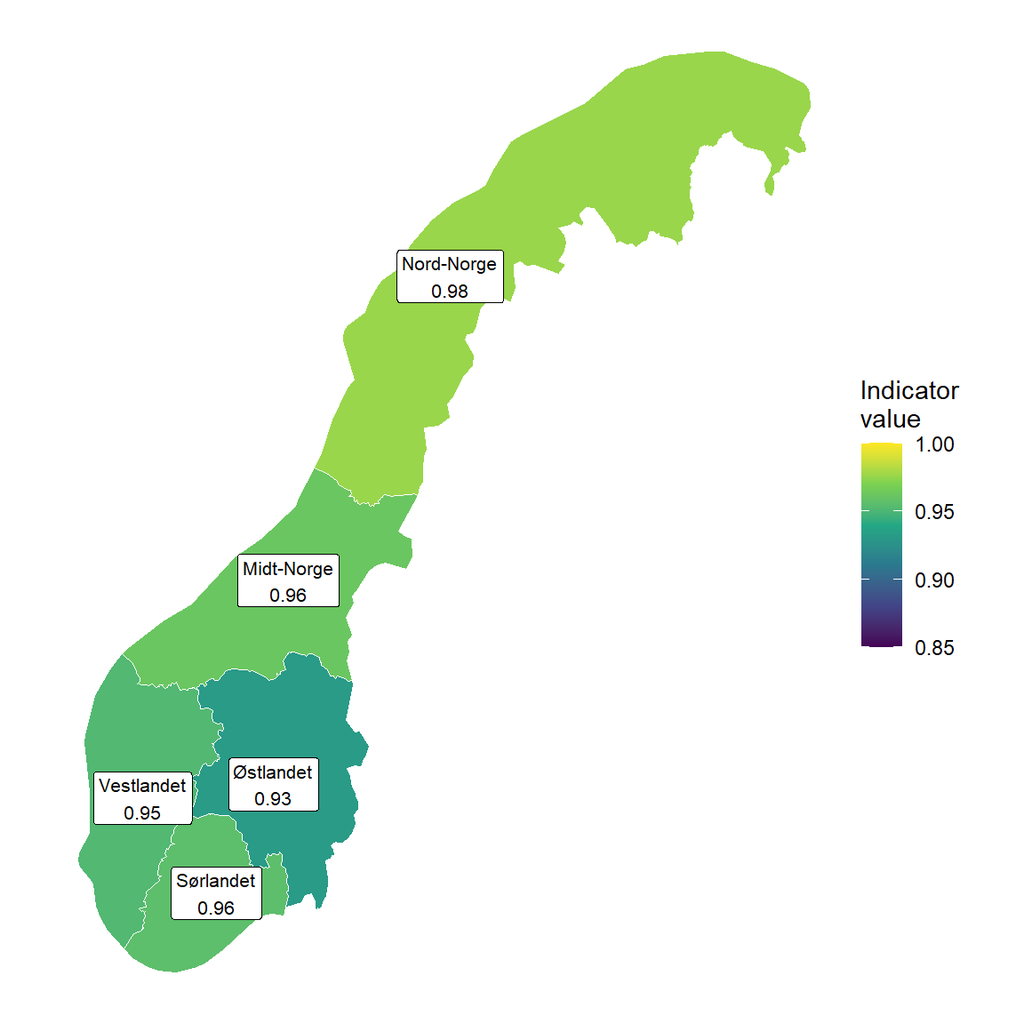

Figure 1: Indicator values per region

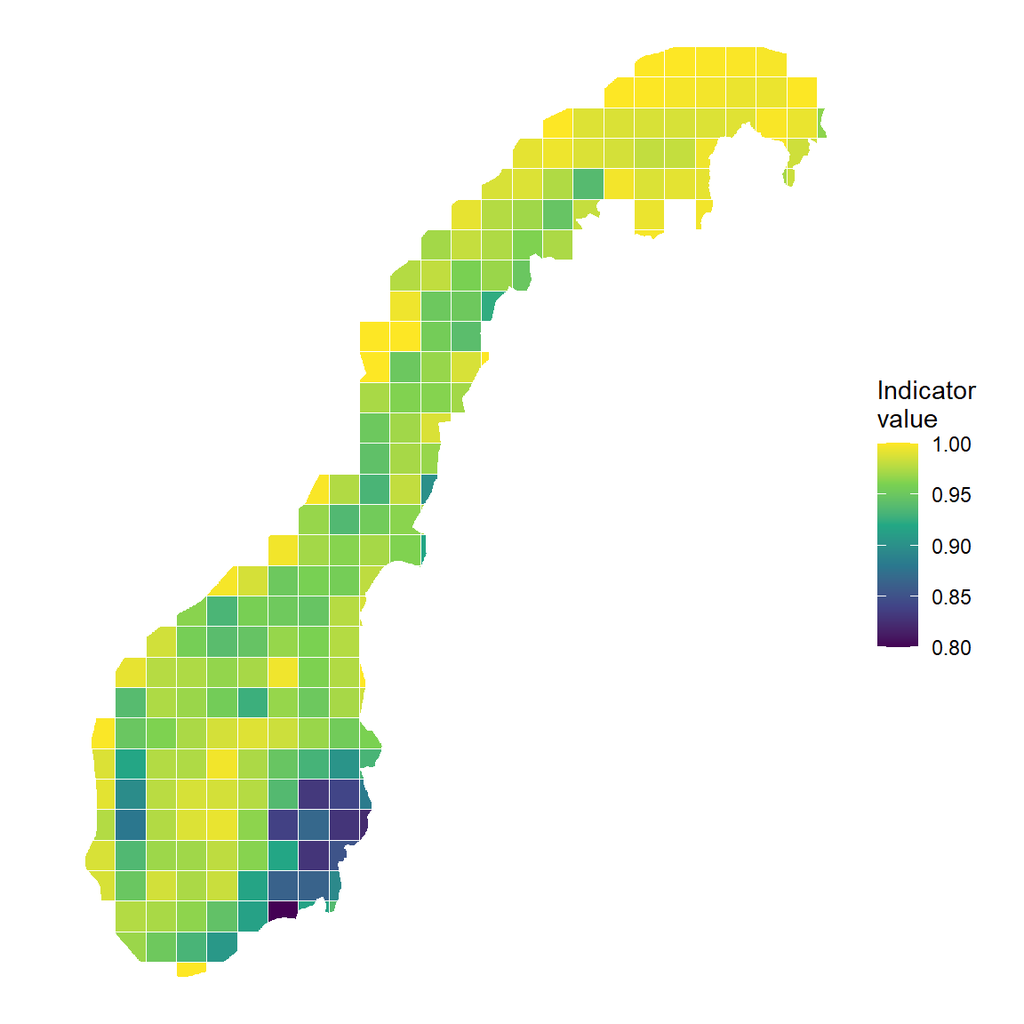

Figure 2: Indicator values per 50 km cell

Table 5: Comparison with VAAT-GJEN-01. With the same weighting of strata (i_sample_design), the two measure the same population

| Region | VAAT-GJEN-01 (LiDAR, sample) | VAAT-GJEN-02, strata weighted equally | VAAT-GJEN-02, weighted by mire area |
| --- | --- | --- | --- |
| Norge | 0.949 | 0.952 | 0.953 |
| Nord-Norge | 0.977 | 0.977 | 0.976 |
| Midt-Norge | 0.960 | 0.959 | 0.962 |
| Vestlandet | 0.959 | 0.963 | 0.952 |
| Østlandet | 0.908 | 0.914 | 0.932 |
| Sørlandet | 0.950 | 0.957 | 0.956 |

## 11. Export file

The tables of the national run are converted to the ecosystemCondition platform format by `R/export_deliverables_20m_cells.R`.

```r
# ============================================================
# VAAT-GJEN-02 - deliverables from the orthophoto 20 m cell indicator
# (src/chm_national/cell_indicator.py), in the platform format of the other
# indicators (Tools/export_platform_format.R).
#
# Reads the tables of the national cell run, kept in the repository as
#   ../data/OpenS_data/orthophoto_chmv2_20m_cells/
#     region.csv, grid50km.csv, norway.csv, strata.csv, excluded.csv, uncertainty.csv,
#     sums_by_stratum_and_grid50km.csv, provenance.json
# (copied from <NATIONAL_CHM_OUT_DIR>/cell_indicator_chmv2/; the 20 m rasters
# stay there), and writes to ../outputs/deliverables/:
#   VAAT-GJEN-02_indicatorMap_region.rds     5 landsdeler (primary)
#   VAAT-GJEN-02_indicatorMap_grid50km.rds   SSB 50 km cells with mire
#   VAAT-GJEN-02_values.csv / .xlsx          region rows + national row,
#                                           metadata sheet, grid sheet
#   VAAT-GJEN-02_map.png
#
# Column mapping (platform <- cell tables):
#   YYYY            <- median flight year over Norway's mire (norway.csv), or VAAT_GJEN_02_DATA_YEAR
#   v_YYYY          <- height_m_raised_to_X100: mean calibrated vegetation height
#                     of the unit's AR5 mire, heights below X100 raised to X100
#                     (VAAT-GJEN-01's variable)
#   i_YYYY          <- index_area_weighted: mean of the 20 m cell values,
#                     each cell weighted by its mire area
#   sd_YYYY         <- uncertainty.csv: how far the photo-based indicator lies from
#                     the LiDAR-based one at ~25,000 validation cells, per region
#                     and Norway (sqrt(mean difference^2 + SE^2)); a 50 km square
#                     gets the value of the region holding most of its mire
#   reference_high  <- X100_ref, reference_low <- X0_skog (stratum values,
#                     averaged over the unit's mire area)
#   thr             <- 0.6 (platform default, as VAAT-GJEN-01)
# Supplementary columns (csv/xlsx only): i_sample_design (each region x zone
# stratum weighted equally, as VAAT-GJEN-01's sample), height_m (calibrated
# height without raising), n_cells, mire_km2, flight_year_median / _min / _max.
# ============================================================

suppressPackageStartupMessages({ library(sf); library(dplyr); library(readr); library(jsonlite) })

if (requireNamespace("rstudioapi", quietly = TRUE) && rstudioapi::isAvailable()) {
  setwd(dirname(rstudioapi::getActiveDocumentContext()$path))
} else {
  cmd_args <- commandArgs(trailingOnly = FALSE); fm <- grep("^--file=", cmd_args)
  if (length(fm)) setwd(dirname(normalizePath(sub("^--file=", "", cmd_args[fm]))))
}
source(file.path("..", "..", "Tools", "export_platform_format.R"))

ID        <- "VAAT-GJEN-02"
VERSION   <- Sys.getenv("VAAT_GJEN_02_DELIVERY_VERSION", "000.004")
THR       <- 0.6

in_dir  <- file.path("..", "data", "OpenS_data", "orthophoto_chmv2_20m_cells")
out_dir <- Sys.getenv("VAAT_GJEN_02_DELIVERABLES_DIR", file.path("..", "outputs", "deliverables"))
g1_dir  <- file.path("..", "..", "VAAT-GJEN-01", "data", "OpenS_data")

region_ids <- c("Nord-Norge" = 1L, "Midt-Norge" = 2L, "Østlandet" = 3L, "Vestlandet" = 4L, "Sørlandet" = 5L)

prov <- fromJSON(file.path(in_dir, "provenance.json"))
if (!isTRUE(prov$complete)) stop("The cell run in ", in_dir, " is not complete (see provenance.json)")
reg  <- read_csv(file.path(in_dir, "region.csv"), show_col_types = FALSE)
grid <- read_csv(file.path(in_dir, "grid50km.csv"), show_col_types = FALSE, col_types = cols(SSBID = "c"))
nat  <- read_csv(file.path(in_dir, "norway.csv"), show_col_types = FALSE)
# Year label: the median flight year of the photos over Norway's AR5 mire area
# (each cell dated by the mosaic's flight project visible there).
DATA_YEAR <- as.integer(Sys.getenv("VAAT_GJEN_02_DATA_YEAR", nat$flight_year_median))
cat("Inputs:", nrow(reg), "regions,", nrow(grid), "grid rows, national mire",
    round(nat$mire_km2), "km2 in", nat$n_cells, "cells\n")

to_long <- function(d) d %>% mutate(
  year = DATA_YEAR, v = height_m_raised_to_X100, i = index_area_weighted,
  reference_high = X100_ref, reference_low = X0_skog, thr = THR,
  i_sample_design = index_sample_design, height_m = height_m, n_cells = n_cells, mire_km2 = mire_km2,
  flight_year_median = flight_year_median, flight_year_min = flight_year_min, flight_year_max = flight_year_max)
cols <- c("area", "areaId", "year", "v", "sd", "i", "reference_high", "reference_low", "thr",
          "i_sample_design", "height_m", "n_cells", "mire_km2", "flight_year_median", "flight_year_min", "flight_year_max")

# --- region (primary) ---------------------------------------------------
regions <- st_read(file.path(g1_dir, "regions.shp"), quiet = TRUE, options = "ENCODING=UTF-8") %>%
  st_transform(25833) %>% select(region)
stopifnot(setequal(reg$region, names(region_ids)), all(reg$region %in% regions$region))
unc <- read_csv(file.path(in_dir, "uncertainty.csv"), show_col_types = FALSE)
stopifnot(all(c(reg$region, "Norge") %in% unc$region))
sd_of <- setNames(unc$sd, unc$region)
region_long <- regions %>% inner_join(to_long(reg) %>% mutate(sd = unname(sd_of[region])), by = "region") %>%
  mutate(area = region, areaId = unname(region_ids[region])) %>%
  select(all_of(cols)) %>% arrange(areaId)

# --- 50 km grid (cells with mire; cells whose centre lies outside the
#     SSB grid have no SSBID and are only in the regional/national values) ---
ssb50 <- st_read(file.path(g1_dir, "ssb50km.shp"), quiet = TRUE) %>% st_transform(25833) %>% select(SSBID)
grid <- grid %>% filter(!is.na(SSBID))
main_region <- read_csv(file.path(in_dir, "sums_by_stratum_and_grid50km.csv"), show_col_types = FALSE,
                        col_types = cols(SSBID = "c")) %>%
  filter(!is.na(SSBID)) %>% group_by(SSBID, region) %>% summarise(km2 = sum(mire_km2), .groups = "drop") %>%
  group_by(SSBID) %>% slice_max(km2, n = 1, with_ties = FALSE) %>% ungroup() %>% select(SSBID, main_region = region)
grid <- grid %>% left_join(main_region, by = "SSBID") %>% mutate(sd = unname(sd_of[main_region]))
stopifnot(all(grid$SSBID %in% ssb50$SSBID))
grid_long <- ssb50 %>% inner_join(to_long(grid), by = "SSBID") %>%
  mutate(area = paste0("SSB50km_", SSBID), areaId = as.integer(SSBID)) %>%
  select(all_of(cols))

# --- national row ----------------------------------------------------------
national <- to_long(nat) %>% mutate(area = "Norge", areaId = 0L, sd = unname(sd_of["Norge"])) %>% select(all_of(cols))

excl <- read_csv(file.path(in_dir, "excluded.csv"), col_names = c("what", "value"), skip = 1, show_col_types = FALSE)
cal <- prov$calibration

# --- metadata sheet ---------------------------------------------------------
metadata <- c(
  "Indicator ID"                 = ID,
  "Version"                      = VERSION,
  "Indicator name (public)"      = "Gjengroing i våtmark (flyfoto)",
  "Indicator name (technical)"   = "Woody encroachment in wetlands - vegetation height from aerial orthophoto (CHMv2 canopy-height model, calibrated to LiDAR) relative to good-condition reference",
  "Ecosystem"                    = "Våtmark (wetland); IUCN GET TF1.6 Boreal/temperate bogs, TF1.7 Boreal/temperate fens",
  "ECT class"                    = "B2 - Structural State Characteristics",
  "Spatial units delivered"      = "landsdel (5 regions, primary map), SSB 50 km grid cells with AR5 mire; national value in the values table (area = Norge). Computed from all 20 m cells of AR5 mire (wall-to-wall)",
  "CRS"                          = "EPSG:25833 (ETRS89 / UTM 33N)",
  "Data year label"              = paste0(DATA_YEAR, " - label required by the platform's column convention: median flight year of the photos over the AR5 mire area of Norway (photos from ", nat$flight_year_min, " to ", nat$flight_year_max, "). Each 20 m cell is dated by the flight project visible there in the 2025 national orthophoto mosaic; median, earliest and latest flight year per unit are in the columns flight_year_*"),
  "Variable (v)"                 = "Mean vegetation height (m) of the unit's AR5 mire: per 20 m cell the median of the 0.5 m CHMv2 heights, calibrated to LiDAR, heights below the stratum's reference raised to it (as VAAT-GJEN-01); mean over cells weighted by mire area",
  "Indicator (i)"                = "1 - sigmoid(cell height scaled between reference_low and reference_high of the cell's stratum), per 20 m cell; 1 = reference condition (no encroachment), 0 = forest height. Unit value = mean over the unit's cells weighted by their AR5 mire area. Column i_sample_design: the same with every region x bioclimatic-zone stratum weighted equally, as in VAAT-GJEN-01's sample",
  "Scaling function"             = "Sigmoid: 100.68 * (1 - exp(-5 * x^2.5)) / 100 on x = (v - X100) / (X0 - X100) clipped to [0, 1], then inverted (shorter vegetation = better). Same function as VAAT-GJEN-01",
  "reference_high (X100)"        = "From VAAT-GJEN-01, per region x bioclimatic-zone stratum: good-condition NiN wetland polygons, canopy height evaluated at 30 m, median per polygon, then median across polygons. Unit value = stratum values averaged over the unit's mire area",
  "reference_low (X0)"           = "From VAAT-GJEN-01, per stratum: 90th percentile of canopy height in AR5 forest sample cells (20 m). Unit value = stratum values averaged over the unit's mire area",
  "Threshold (thr)"              = "0.6 on the indicator scale = platform default, as VAAT-GJEN-01",
  "Uncertainty (sd)"             = paste0("Agreement with the LiDAR-based indicator (VAAT-GJEN-01 method) at ", unc$n_validation_cells[unc$region == "Norge"], " validation cells (20 m) in AR5 mire: the indicator is computed at each cell from LiDAR height and from the calibrated photo-based height (calibration fitted without the cell's region); sd = sqrt(mean difference^2 + SE^2), SE from 1000 bootstrap resamples of the cells. Region and national values from the cells in the unit; a 50 km square gets the value of the region holding most of its mire"),
  "Calibration"                  = paste0("LiDAR height = max(0, ", cal$a, " + ", cal$b, " x CHMv2 height), 20 m cell medians; fitted on ", cal$points),
  "Number of observations"       = paste0(nat$n_cells, " cells of 20 m x 20 m (", round(nat$mire_km2), " km2 of AR5 mire); per-unit n_cells in the tables. Left out: ",
                                          paste0(excl$what, " ", format(excl$value, big.mark = ",", scientific = FALSE, trim = TRUE), collapse = "; ")),
  "Justification of references"  = "As VAAT-GJEN-01: reference condition = vegetation height of wetland mapped in good ecological condition (NiN tilstand 'god'); X0 = forest, the end state of encroachment",
  "Data sources"                 = "National 50 cm RGB orthophoto mosaic (Norge i bilder); CHMv2 canopy-height model (Meta / World Resources Institute, open weights); AR5 mire (NIBIO FKB-AR5); OpenStreetMap buildings; references from VAAT-GJEN-01 (Kartverket DTM1/DOM1, AR5, NiN); Moen bioclimatic zones; SSB grid via Kartverket",
  "Method note"                  = "Replaces the earlier VAAT-GJEN-02 version based on NiN wetland polygons. Same cells, height measure, references and scaling as VAAT-GJEN-01, but every 20 m cell of AR5 mire instead of a sample",
  "Documentation"                = "https://github.com/Chimal93/wetland_condition_indicators/tree/main/VAAT-GJEN-02",
  "Column spelling note"         = "reference_high / reference_low as in the platform's example file; the platform docs and the contract text spell them referance_*",
  "Produced by"                  = "Sállir Natur AS",
  "Generated"                    = format(Sys.time(), "%Y-%m-%d %H:%M")
)

export_platform_indicator(
  id        = ID,
  units     = list(region = region_long, grid50km = grid_long),
  national  = national,
  metadata  = metadata,
  out_dir   = out_dir,
  png_title = "VAAT-GJEN-02 - Gjengroing i våtmark (flyfoto)"
)
```

## 12. Author contributions

**CRediT statement**

- Software (code development): JACB, LK
- Validation (assessment): JACB, LK
- Writing of the project report: BS, JACB

BS: Bendik Sivertsen. JACB: Jesus Adrian Chimal-Ballesteros. LK: Lasse Keetz.

AI tools: Claude (Anthropic) was used for code development and review, for running and checking analyses, and for drafting this document. The use is described in the repository README.

**TipSession Info**

This is the R session that rendered the document, not the one that produced the results. The package versions of the analysis are in `renv.lock` and `src/chm_national/uv.lock`.